# Mixed DPs, pilot

# Overview

The original dataset (prepilot) contains 333 DPs produced by 10 participants. 34 out of 333 do not include our target Basque lemma, and 12 do not include a Spanish DET (in all these cases, the produced noun corresponds to a full Basque DP, as it always ends with the suffix -a (sing) or -ak (pl)).

The final dataset contains 287 mixed DPs by 10 participants where the produced noun matches our target Basque lemma, and a Spanish DET is included.

Each participant is presented with 32 different images (i.e. 32 target lemmas). On average, each participant has produced 29 mixed DPs matching our experimental criteria.

We also exclude from the analysis plural DPs, since the focus of the study is gender assignment in singular DPs. Plural DPs account for 2% of the data (n=7).

| detNumber | n | proportion |
| --- | --- | --- |
| p | 7 | 0.0243902 |
| s | 280 | 0.9756098 |

Number of mixed DPs per participant:

| participant | n |
| --- | --- |
| 1 | 30 |
| 2 | 31 |
| 3 | 24 |
| 4 | 27 |
| 5 | 28 |
| 6 | 28 |
| 7 | 23 |
| 8 | 32 |
| 9 | 31 |
| 10 | 33 |

There are 12 cases where a participant produces more than one DP for a single lemma (i.e. image). In some cases (e.g. participant #5, #6), one instance uses a Basque noun, while the other uses a Spanish noun (la gota, la tanta; el verano, el uda). In other cases (e.g. participant #10), one instance includes the Basque DET -a, while the other does not (el ogi, el ogia; el komun, la komuna). This last case is interesting because the addition of the -a suffix correlates with a change in the gender of the DET. We have observed this only once.

Frequency of Spanish determiners used in the mixed DPs:

| det | n | proportion |
| --- | --- | --- |
| el | 141 | 0.4912892 |
| la | 137 | 0.4773519 |
| los | 6 | 0.0209059 |
| las | 1 | 0.0034843 |
| un | 1 | 0.0034843 |
| una | 1 | 0.0034843 |

# Analogical gender

If the gender of the produced Spanish DET matches the gender of the produced Basque noun’s Spanish translation, we can infer that the employed strategy is analogical gender. How often do participants use analogical gender assignment? (decreasing order from highest to lowest use of analogical gender)

| participant | n_analogical | proportion_analogical | total_DPs |
| --- | --- | --- | --- |
| 1 | 27 | 0.9642857 | 28 |
| 6 | 27 | 0.9642857 | 28 |
| 4 | 24 | 0.9230769 | 26 |
| 3 | 22 | 0.9166667 | 24 |
| 9 | 26 | 0.8666667 | 30 |
| 10 | 26 | 0.8387097 | 31 |
| 2 | 25 | 0.8333333 | 30 |
| 5 | 22 | 0.7857143 | 28 |
| 7 | 17 | 0.7391304 | 23 |
| 8 | 18 | 0.5625000 | 32 |

```
##   participant     n_analogical  proportion_analogical   total_DPs
##  Min.   : 1.00   Min.   :17.0   Min.   :0.5625        Min.   :23.0
##  1st Qu.: 3.25   1st Qu.:22.0   1st Qu.:0.7976        1st Qu.:26.5
##  Median : 5.50   Median :24.5   Median :0.8527        Median :28.0
##  Mean   : 5.50   Mean   :23.4   Mean   :0.8394        Mean   :28.0
##  3rd Qu.: 7.75   3rd Qu.:26.0   3rd Qu.:0.9215        3rd Qu.:30.0
##  Max.   :10.00   Max.   :27.0   Max.   :0.9643        Max.   :32.0
```

Lower outlier cut-off point:

```
## [1] 0.5948917
```

Filter trials with non-analogical gender

# Phonological ending

## -a ending

1/4 of the images (n=8) correspond to a Basque target lemma ending in -a. Almost all DPs including these lemmas also end in -a, except for 2 cases where the plural ending -ak is used.

| last_phone | n | proportion |
| --- | --- | --- |
| a | 69 | 0.971831 |
| k | 2 | 0.028169 |

The remaining 3/4 of the target stimuli (n=24) correspond to a target lemma where the final phoneme is not /a/. However, (…) citation forms in Basque include the DET -a. In the experiment, when participants use a mixed DP with a lemma not ending in -a, they include the -a suffix most of the times (72%).

| last_phone | n | proportion |
| --- | --- | --- |
| a | 151 | 0.7224880 |
| i | 23 | 0.1100478 |
| n | 10 | 0.0478469 |
| o | 25 | 0.1196172 |

Side note (maybe for future experiments). Adding the suffix -a increases the number of syllables of the word by +1. If the Basque lemma employed in the DP is 3-syllables long, it is much less likely that the suffix -a is added: participants add the suffix -a 81% of the times for 2-syllable lemmas (127/30), but only 46% of the times for 3-syllable lemmas (24/28). A chi-squared test of independence reveals this is statistically significant ($\chi^2$=16.182, df=1, p=5.755e-05). Possible prosodic explanation.

| lemma_syllables | a_suffix_added | n | proportion |
| --- | --- | --- | --- |
| 2 | 0 | 30 | 0.1910828 |
| 2 | 1 | 127 | 0.8089172 |
| 3 | 0 | 28 | 0.5384615 |
| 3 | 1 | 24 | 0.4615385 |

```
##
##  Pearson's Chi-squared test with Yates' continuity correction
##
## data:  .
## X-squared = 16.182, df = 1, p-value = 5.755e-05
```

## Phonological gender

In Spanish, -a nouns are prototypically feminine, and -o nouns masculine. This can bias the gender assignment in at least two ways: (1) the last phoneme of the produced *noun* determines the gender of the mixed DP; (2) the last phoneme of the underlying *lemma* determines the gender of the mixed DP. We test this on a subset of the data, selecting only -a and -o endings (and ignoring -i and -n), as these show the strongest gender effects in the Spanish lexicon.

Does the phonological ending of the noun affect the gender assignment? Yes; these two variables (prototypical gender for noun’s phonological ending, and gender of the produced DET) are *dependent* according to a a Chi-squared test (p=0.000158). This is most clearly seen in the case of nouns ending in -o, which are prototypically masculine in Spanish, and where participants choose a masculine DET in 88% of the produced mixed DPs.

| noun_phon_gender | detGender | n | proportion |
| --- | --- | --- | --- |
| f | f | 119 | 0.5409091 |
| f | m | 101 | 0.4590909 |
| m | f | 3 | 0.1200000 |
| m | m | 22 | 0.8800000 |

```
##
##  Pearson's Chi-squared test with Yates' continuity correction
##
## data:  .
## X-squared = 14.27, df = 1, p-value = 0.0001584
```

| lemma_phon_gender | detGender | n | proportion |
| --- | --- | --- | --- |
| f | f | 42 | 0.5915493 |
| f | m | 29 | 0.4084507 |
| m | f | 30 | 0.3896104 |
| m | m | 47 | 0.6103896 |

```
##
##  Pearson's Chi-squared test with Yates' continuity correction
##
## data:  .
## X-squared = 5.2486, df = 1, p-value = 0.02196
```

# Statistical models

Chi-squared test for independence between (1) analogical gender, (2) det gender.

```
##
##  Pearson's Chi-squared test with Yates' continuity correction
##
## data:  .
## X-squared = 123.58, df = 1, p-value < 2.2e-16
```

| participant | analog_p |
| --- | --- |
| 1 | 0.0000054 |
| 2 | 0.0007962 |
| 3 | 0.0002137 |
| 4 | 0.0000701 |
| 5 | 0.0075138 |
| 6 | 0.0000054 |
| 7 | 0.0200673 |
| 8 | 0.6830914 |
| 9 | 0.0002607 |
| 10 | 0.0004849 |

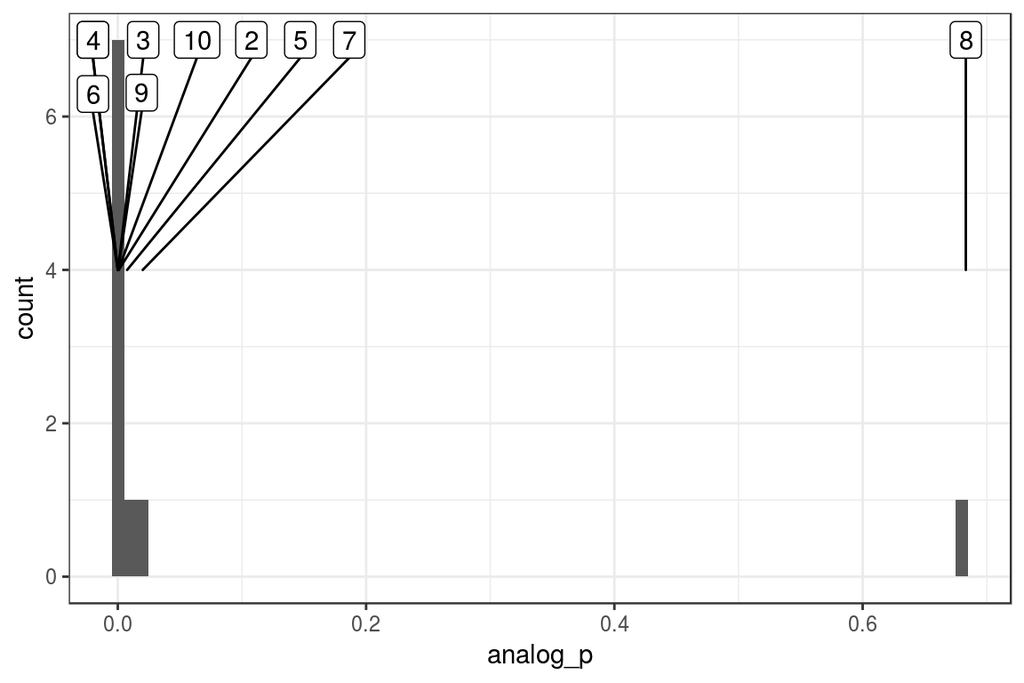

## Individual participants

As seen before, #8 (the only L1 Basque) is an outlier (p=0.683). #8 shows an overall bias towards using fem DET. Below, see the 8 instances where #8 uses a masc DET. Interestingly, none of these DPs involve a lemma ending in -a (the prototypically feminine ending), so gender assignment could be driven by the phonological ending of the lemma. However, #8 uses the fem DET *la* for nouns like *mokoa*, *besoa*, and *lepoa*, which have -o ending lemmas and masc translation (although they include the -a suffix).

|  | det_f | det_m |
| --- | --- | --- |
| analog_f | 13 | 3 |
| analog_m | 11 | 5 |

| participant | trial | det | noun | lemma | last_phone_noun | last_phone_lemma | analog_gender |
| --- | --- | --- | --- | --- | --- | --- | --- |
| 8 | 6 | el | ogia | ogi | a | i | analog_m |
| 8 | 11 | el | eguzkia | eguzki | a | i | analog_m |
| 8 | 15 | el | begia | begi | a | i | analog_m |
| 8 | 17 | el | ezpaina | ezpain | a | n | analog_m |
| 8 | 20 | el | soinekoa | soineko | a | o | analog_m |
| 8 | 23 | el | poxpolo | pospolo | o | o | analog_f |
| 8 | 23 | el | poxpoloa | pospolo | a | o | analog_f |
| 8 | 32 | el | hostoa | hosto | a | o | analog_f |

The other participant for whom analogical gender assignment is not robust is #7 (p=0.02). In this case, however, all the nouns with masc translation get a masc DET. That is, analogical gender explains those nouns, but not the ones with fem translation.

|  | det_f | det_m |
| --- | --- | --- |
| analog_f | 7 | 6 |
| analog_m | 0 | 10 |

| participant | trial | det | noun | lemma | last_phone_noun | last_phone_lemma | det_gender |
| --- | --- | --- | --- | --- | --- | --- | --- |
| 7 | 1 | el | eztia | ezti | a | i | det_m |
| 7 | 3 | la | tipula | tipula | a | a | det_f |
| 7 | 5 | la | soka | soka | a | a | det_f |
| 7 | 8 | la | gona | gona | a | a | det_f |
| 7 | 12 | la | lainoa | laino | a | o | det_f |
| 7 | 19 | el | belauna | belaun | a | n | det_m |
| 7 | 22 | la | tanta | tanta | a | a | det_f |
| 7 | 23 | el | poxpoloa | pospolo | a | o | det_m |
| 7 | 24 | la | txanpoña | txanpon | a | n | det_f |
| 7 | 25 | el | malkoa | malko | a | o | det_m |
| 7 | 28 | la | leihoa | leiho | a | o | det_f |
| 7 | 29 | el | ilargia | ilargi | a | i | det_m |
| 7 | 32 | el | hostoa | hosto | a | o | det_m |

```
##
## Call:
## glm(formula = det_gender ~ analog_gender, family = binomial(link = "logit"),
##     data = d)
##
## Deviance Residuals:
##     Min       1Q   Median       3Q      Max
## -1.9239  -0.6133   0.5847   0.5847   1.8781
##
## Coefficients:
##                       Estimate Std. Error z value Pr(>|z|)
## (Intercept)            -1.5755     0.2242  -7.026 2.12e-12 ***
## analog_genderanalog_m   3.2552     0.3228  10.084  < 2e-16 ***
## ---
## Signif. codes:  0 '***' 0.001 '**' 0.01 '*' 0.05 '.' 0.1 ' ' 1
##
## (Dispersion parameter for binomial family taken to be 1)
##
##     Null deviance: 388.11  on 279  degrees of freedom
## Residual deviance: 250.05  on 278  degrees of freedom
## AIC: 254.05
##
## Number of Fisher Scoring iterations: 3
```

```
##
## Call:
## glm(formula = det_gender ~ analog_gender + phon_gender, family = binomial(link = "logit"),
##     data = d_noun_phon_gender)
##
## Deviance Residuals:
##     Min       1Q   Median       3Q      Max
## -1.8134  -0.5141   0.1452   0.6552   2.0441
##
## Coefficients:
##                       Estimate Std. Error z value Pr(>|z|)
## (Intercept)            -1.9571     0.2854  -6.856 7.06e-12 ***
## analog_genderanalog_m   3.3866     0.3731   9.076  < 2e-16 ***
## phon_genderphon_m       3.1173     0.7102   4.389 1.14e-05 ***
## ---
## Signif. codes:  0 '***' 0.001 '**' 0.01 '*' 0.05 '.' 0.1 ' ' 1
##
## (Dispersion parameter for binomial family taken to be 1)
##
##     Null deviance: 339.64  on 244  degrees of freedom
## Residual deviance: 204.58  on 242  degrees of freedom
## AIC: 210.58
##
## Number of Fisher Scoring iterations: 5
```